# Chapter 4. Multivariate Data

- Multivariate data can be summarized and viewed in ways that are similar to those discussed for bivariate and univariate data
- Looking at all the variables simultaneously, or holding some variables constant while looking at others are the two ways to handle multiple variables.

## 4.1 Viewing multivariate data

### 4.1.1 Summarizing categorical data

A table shows only two relationships at once. What should we do to look at three or more relationships?

```r
library(UsingR)
```

```r
# The table contains too much information for us to identify!!
student.expenses
```

| cell.phone | cable.tv | dial.up | cable.modem | car |
| --- | --- | --- | --- | --- |
| Y | Y | Y | N | Y |
| Y | N | N | N | N |
| N | N | N | N | Y |
| Y | Y | N | Y | Y |
| N | N | N | N | N |
| Y | N | Y | N | Y |
| Y | N | N | Y | N |
| N | N | N | N | Y |
| Y | Y | N | N | Y |
| Y | N | Y | N | N |

```r
attach(student.expenses)
names(student.expenses)

# A relationship between having a cell phone and a car can be seen by a table
table(cell.phone, car)
```

1. 'cell.phone'

2. 'cable.tv'

3. 'dial.up'

4. 'cable.modem'

5. 'car'

```
          car
cell.phone N Y
         N 1 2
         Y 3 4
```

**Three-way contingency tables(n-way contingency tables)**  
It shows relationships among three (or *n*) variables using tables.

Let's investigate whether paying for a cable modem affects the relationship between having a cell phone and a car. Use a *three-way table*.

```r
# Paying for a cable modem requires cutbacks elsewhere.
# table() function uses the first two variables for the main tables
# and the remaining variables to construct different tables for each combination
# of the variables.

table(cell.phone, car, cable.modem)
```

```
, , cable.modem = N

          car
cell.phone N Y
         N 1 2
         Y 2 3

, , cable.modem = Y

          car
cell.phone N Y
         N 0 0
         Y 1 1
```

*Flattened contingency tables*

The tables are set side-by-side, with the column headings layered to indicate the levels of the conditioning factor.

```r
# not side-by-side
ftable(table(cell.phone, car, cable.modem))
```

```
               cable.modem N Y
cell.phone car
N          N               1 0
           Y               2 0
Y          N               2 1
           Y               3 1
```

Specify the desired row variables or column variables.

The column variables are set with the argument **col.vars=**.

This argument expects **a vector of variable names** or **indices**.

```r
ftable(table(cell.phone, car, cable.modem), col.vars = c("cable.modem", "car"))
```

```
           cable.modem N   Y
           car         N Y N Y
cell.phone
N                      1 2 0 0
Y                      2 3 1 1
```

```r
detach(student.expenses)
```

### 4.1.2 Comparing independent samples

When we have data for several variables of the same type, we often want to compare their centers, spreads, or distributions. Use **boxplots**.

**ewr(UsingR)**  
taxi-in-and-out data for airplanes landing at Newark Liberty airport.  
The data set contains monthly averages for eight major carreirs.  
Which airlines take off and land faster than the others??

```r
attach(ewr)
names(ewr)
```

1. 'Year'

2. 'Month'

3. 'AA'

4. 'CO'

5. 'DL'

6. 'HP'

7. 'NW'

8. 'TW'

9. 'UA'

10. 'US'

11. 'inorout'

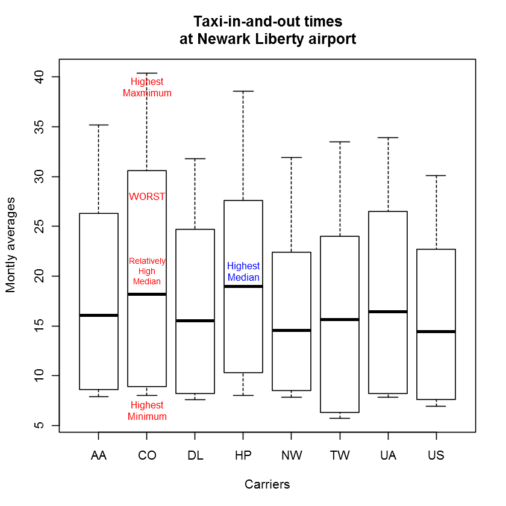

```r
boxplot(AA, CO, DL, HP, NW, TW, UA, US, main="Taxi-in-and-out times\nat Newark Liberty airport",
        names = c("AA", "CO", "DL", "HP", "NW", "TW","UA", "US"),
       xlab = "Carriers", ylab = "Montly averages")
text(2, 28, "WORST", cex=0.8, col="red")
text(2, 20.5, "Relatively\nHigh\nMedian", col="red", cex=0.7)
text(2, 39, "Highest\nMaxmimum", col="red", cex=0.8)
text(2, 6.5, "Highest\nMinimum", col="red", cex=0.8)
text(4, 20.5, "Highest\nMedian", col = "blue", cex=0.8)
detach(ewr)
```

**boxplot()** : make a boxplot **for each data vector** it is called with

It is tedious and prone to errors, as much needs to be typed.

The variable "inorout" indicates whether the time is for taxi in or taxi out.

Taxi-in times should all be about the same.

Taxi-out times are more likely to vary, as the queue to take off varies in length depending on the time of day.

How could we manipulate data to view this difference?

### 4.1.3 Comparing relationships

**Scatterplots()**: used to investigate relationships between two variables.  
They can also be used when there are **more than two variables**.

Use different **plot characters** or **colors** to distinguish the variables in order to plot multiple relationships on the same scatterplot.

**babies(UsingR)**  
Several variables collected from new mothers as part of a study on child health and development.  
The variables include gestation period, maternal age, whether and how much the mother smokes, and other factors, such as mother's level of education.

**A built-in function for creating scatterplots of all possible pairs of variables** : *pairs()*

- The plot of gestation versus weight

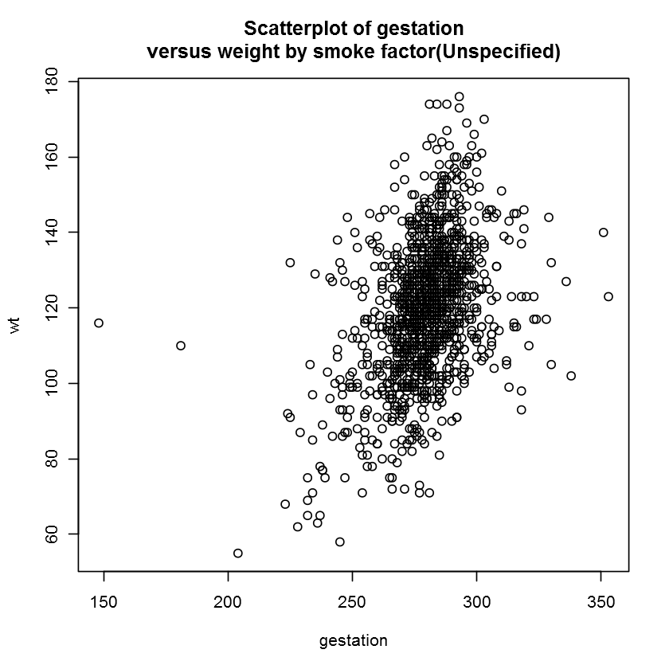

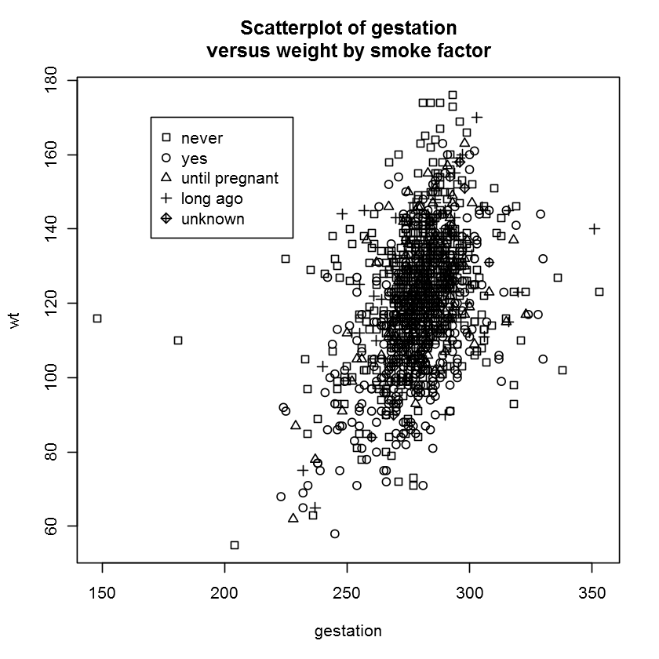

```r
attach(babies)
gestation[gestation == 999] <- NA
plot(gestation, wt, main = "Scatterplot of gestation\nversus weight by smoke factor(Unspecified)")
# A different plot
plot(gestation, wt, pch=smoke, main = "Scatterplot of gestation\nversus weight by smoke factor")
legend(170, 170, legend=c("never", "yes", "until pregnant", "long ago", "unknown"), pch=c(0:3,9))
```

The longer the gestation period, the more time a bay has to increase its birth weight.

To plot with different plot characters, we set the **pch=** argument using another variable to decide the plot character.

The plots above are too crowded. Let's use different colors. Use **col=** argument to change colors.

```r
table(smoke)
```

```
smoke
  0   1   2   3   9
544 484  95 103  10
```

The smoke variable has five "factors" or "categories": "0", "1", "2", "3", "9"

**If we want to use consequent indices for colors** (e.g. 1,2,3,4,5 for five categories) in using the function *rainbow()*...

Currently, the factors are not continuous. So we change "9" to "4" to make the five "categories" form an increasing sequence.

```r
smoke[smoke == 9] <- 4
```

Then, we add 1 to all those factors, as "col = 0" is not defined.

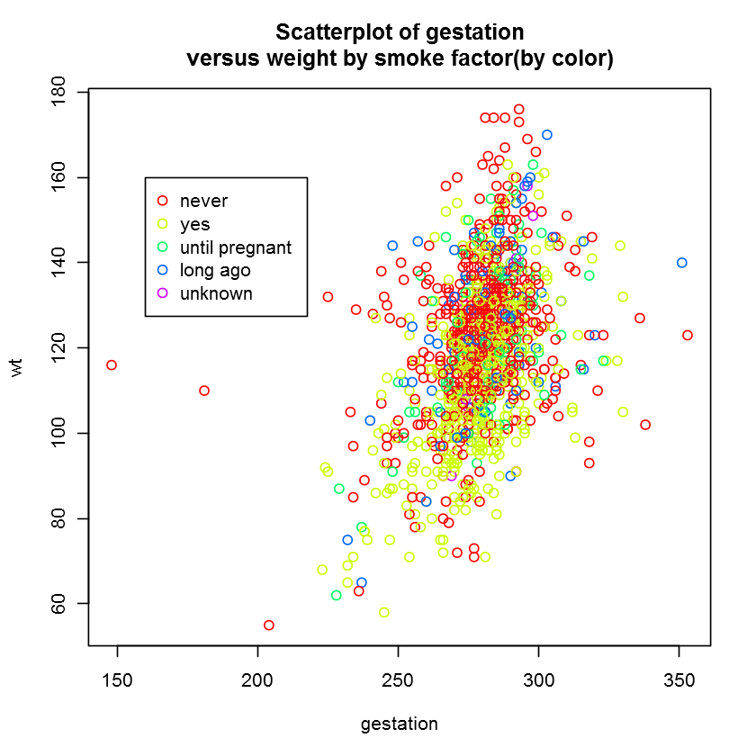

```r
plot(gestation, wt, col=rainbow(5)[smoke+1], main = "Scatterplot of gestation\nversus weight by smoke factor(by color)")
legend(160, 160, c("never", "yes", "until pregnant", "long ago", "unknown"),
       pch=rep(1,5),col=rainbow(5))
```

Still, no additional trends show up.

Different scatterplots for each level of the smoke factor?

Subset the data, or use the lattice package.

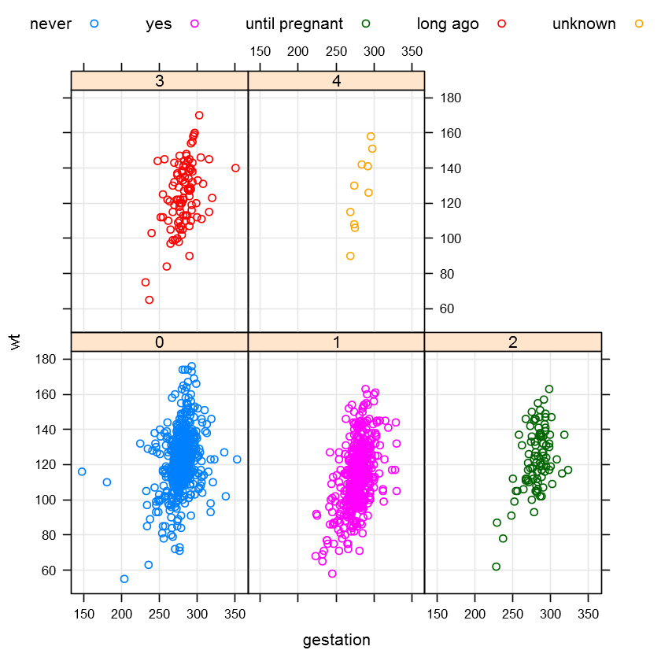

```r
# We will study how to use lattice package later...
library(lattice)
xyplot(wt~gestation|factor(smoke),
       groups = factor(smoke,labels=c("never","yes",'until pregnant','long ago','unknown')),
      type=c("p", "g"), auto.key=list(columns=5))
```

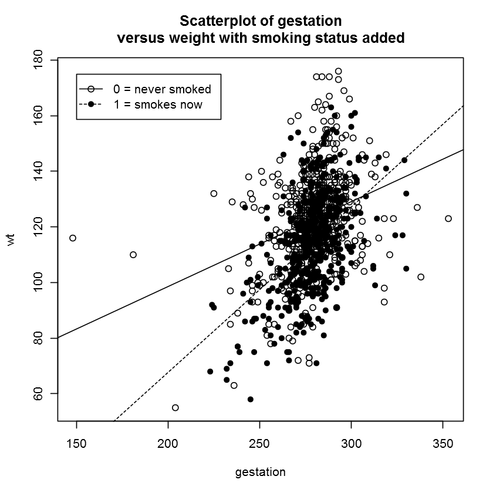

```r
f <- wt[smoke == 0] ~ gestation[smoke == 0]
plot(f, xlab="gestation", ylab="wt", main = "Scatterplot of gestation\nversus weight with smoking status added")
abline(lm(f))
f1 <- wt[smoke == 1] ~ gestation[smoke==1]
points(f1, pch=16)
# another regression line with different line type and line size
abline(lm(f1), cex=2, lty=2)
legend(150, 175, legend=c("0 = never smoked", "1 = smokes now"),
      pch = c(1,16), lty=1:2)
detach(babies)
```

## 4.2 R basics: data frames and lists

Multivariate data consists of multiple data vectors considered as a whole.

Combining all those separate variables into a single data object has many advantages.

These "objects" are usually **DATA FRAMES** in R.

A data frame is used to store **rectangular grids of data**.

- Each row: measurements on the same subject, statistical unit, or experimental unit.
- Each column: a data vector containing data for one of the variables.

The collection of entries need not all be of the same type, but **each column must contain the same type of entry** as they are **data vectors!!!**.

A rectangular collection of values, **all of the same type**, may also be stored in a **matrix**.

**List**  
A more general type of storage than a data frame. Think of a list as a collection of *components*. Each component can be any R object, such as a vector, a data frame, a function, or even another list.

A data frame is a list with top-level components given by **equal-length data vectors**.

```r
x <- 1:2
# y = c("a", "b")
y <- letters[1:2]
z <- 1:3
dt1 <- data.frame(x,y)

# Error, the top-level components are not equal in length.
data.frame(x,y,z)
```

```
Error in data.frame(x, y, z): arguments imply differing number of rows: 2, 3
Traceback:

1. data.frame(x, y, z)
2. stop(gettextf("arguments imply differing number of rows: %s",
 .     paste(unique(nrows), collapse = ", ")), domain = NA)
```

```r
dt1
```

| x | y |
| --- | --- |
| 1 | a |
| 2 | b |

A list is a very flexible type of data object. Many of the functions in R, such as lm(), have return values that are lists.

Lists can be used to store variables of different lengths.

```r
ls1 <- list(x,y,z)
ls1
```

1. 1. 1

   2. 2

2. 1. 'a'

   2. 'b'

3. 1. 1

   2. 2

   3. 3

**[[1]]** says this is for the first **toplevel** component of the list, which is a **data vector**.

The following **[1]** refers to the first entry of this data vector.

One difference that isn’t apparent in the output, when using data.frame to create a data frame, is that character variables, such as y, are coerced to be factors, unless insulated with I.

```r
# See that y has the data type - "factor", instead of "character"
str(dt1)
```

```
'data.frame':	2 obs. of  2 variables:
 $ x: int  1 2
 $ y: Factor w/ 2 levels "a","b": 1 2
```

```r
## Insulate with I() to maintain its type.
dt2 <- data.frame(x, I(y))
str(dt2)
```

```
'data.frame':	2 obs. of  2 variables:
 $ x: int  1 2
 $ y:Class 'AsIs'  chr [1:2] "a" "b"
```

```r
## The coercion isn't done by list(). y is "chr"
str(ls1)
```

```
List of 3
 $ : int [1:2] 1 2
 $ : chr [1:2] "a" "b"
 $ : int [1:3] 1 2 3
```

*Adding names to a data frame or list*

Just like data vectors, both data frames and lists can have a names attribute. These are **found and set** by the *names()* function or when we define the object. The names of a list refer to the top-level components.

For data frames, these top-level components are the **variables**. In the above examples, the command data.frame(x,y) assigns names of x and y automatically, but the list() function does not. If we want to define names when using data.frame() or list() we can use a **name=value** format, as in

```r
list(x.name=x, "y name" = y)
```

**$x.name**

1. 1

2. 2

**$`y name`**

1. 'a'

2. 'b'

The names() function can be used to retrieve or assign the names. When assigning names it is used on the left side of the assignment (when using the equals sign). For example:

```r
eg <- data.frame(x,y)
# See the current variable names
names(eg)
```

1. 'x'

2. 'y'

```r
# Change the names with the same function, names()
# Does not return anything
names(eg) <- c("x.name", "y name")

# Check the changed names.
# names() returns the variable names of the 'eg' data frame.
names(eg)
```

1. 'x.name'

2. 'y name'

Data frames can also have their column names accessed with the function colnames() and their rows named with rownames(). Both can be set at the same time with dimnames(). The row names must be unique, and it is recommended that column names be also. These functions are applicable to matrix-like objects.

```r
eg
```

| x.name | y name |
| --- | --- |
| 1 | a |
| 2 | b |

```r
# See the current column names of the data frame 'eg'.
colnames(eg)
```

1. 'x.name'

2. 'y name'

```r
# change names again with the same function, colnames()
colnames(eg) <- c("hi", "there")

# Check the changed names.
colnames(eg)
```

1. 'hi'

2. 'there'

```r
# You can also check and change the names of rows with rownames()
# If no specific names are assigned, numbers are assigned as default names.
rownames(eg)
```

1. '1'

2. '2'

```r
# Let's change row names
rownames(eg) <- c("What's", "Your name?")
rownames(eg)
```

1. 'What\'s'

2. 'Your name?'

```r
# Wow.
eg
```

|  | hi | there |
| --- | --- | --- |
| What's | 1 | a |
| Your name? | 2 | b |

*The size of a data frame or list*

Data frames represent a number of variables, each with the same number of entries. The ewr (UsingR) is an example. As this data is matrix-like, its size is determined by the number of rows and columns. The **dim()** function returns the size of matrix-like objects:

```r
# number of rows, number of columns; the return value is a data vector.
dim(ewr)
str(dim(ewr))
```

1. 46

2. 11

```
 int [1:2] 46 11
```

```r
# Therefore, you can access the second value separately by an index
dim(ewr)[2]
```

11

Row and column sizes may also be found directly with **nrow()** and **ncol()**.

```r
# the number of rows
nrow(ewr)

# the number of columns
ncol(ewr)
```

46

11

A list need not be rectangular. Its size is defined by **the number of top-level components in it**. This is found with the function **length()**. As data frames are lists whose top-level components are data vectors, the length of a data frame is **the number of variables it contains**.

```r
# number of top-level components, or the "variables" of the data frame ewr.
length(ewr)
```

11

### 4.2.2 Accessing values in a data frame

*Accessing variables in a data frame by name*

When R attaches a data frame it makes a copy of the variables. If we make changes to the variables, the data frame is not actually changed. This results in two variables with the same names but different values.

```r
x <- data.frame(a=1:2, b=3:4)
# You cannot find a outside the data frame, 'x'
a
```

```
Error in eval(expr, envir, enclos): 객체 'a'를 찾을 수 없습니다
Traceback:
```

```r
attach(x)
# This is the copy of the variable 'a' in the data frame 'x'
a
```

1. 1

2. 2

```r
# Change a value of the copy.
a[1] <- 5
a
```

1. 5

2. 2

```r
# However, the original data frmae 'x' does not change in its values
x
```

| a | b |
| --- | --- |
| 1 | 3 |
| 2 | 4 |

```r
detach(x)
# An object 'a', previously copied from the variable 'a' of the data frame 'x'
# remains in the global environment
a
```

1. 5

2. 2

```r
# x is still not changed.
x
```

| a | b |
| --- | --- |
| 1 | 3 |
| 2 | 4 |

*Accessing a data frame using [,] notation*

When we use a spreadsheet, we refer to the cell entries by their column names and rows number. Data-frame entries can be referred to by their column names (or numbers) and/or their row names (or numbers).

Entries of a data vector are accessed with the **[]** notation. This allows us to specify the entries we want **by their indices or names**. If df is the data frame, the basic notation is **df[row, column]**

There are two positions to put values, though **we may leave them blank on purpose**. In particular, the value of row can be a *single number* (to access that row), a *vector of numbers* (to access those rows), a *single name* or *vector of names* (to match the row names), a *logical vector* of the appropriate length, or *left blank* to **match all the rows**.

Similarly for the value of column. As with data vectors, rows and columns begin numbering at 1.

```r
df <- data.frame(x=1:3, y=4:6)
rownames(df) <- c("row 1", "row 2", "row 3")
df
```

|  | x | y |
| --- | --- | --- |
| row 1 | 1 | 4 |
| row 2 | 2 | 5 |
| row 3 | 3 | 6 |

```r
# The entry of the third row, second column = 6
df[3,2]
```

6

```r
# This will yield the same result as above
df["row 3", "y"]
```

6

```r
# rows 1, 2, and 3
df[1:3, 1]
```

1. 1

2. 2

3. 3

```r
# rows 1 and 2, columns 1 and 2
df[1:2, 1:2]

# rows 1 and 3, columns 1 and 2
df[c(1,3), 1:2]
```

|  | x | y |
| --- | --- | --- |
| row 1 | 1 | 4 |
| row 2 | 2 | 5 |

|  | x | y |
| --- | --- | --- |
| row 1 | 1 | 4 |
| row 3 | 3 | 6 |

```r
# all rows, column 1 = returns vector
df[,1]
```

1. 1

2. 2

3. 3

```r
# a vector of logical values can be used as well.
# The length of the vector should be equal to the number of rows, or columns
# depending on which dimension you use the vector to refer to.
df[c(F,T,F), ]
```

|  | x | y |
| --- | --- | --- |
| row 2 | 2 | 5 |

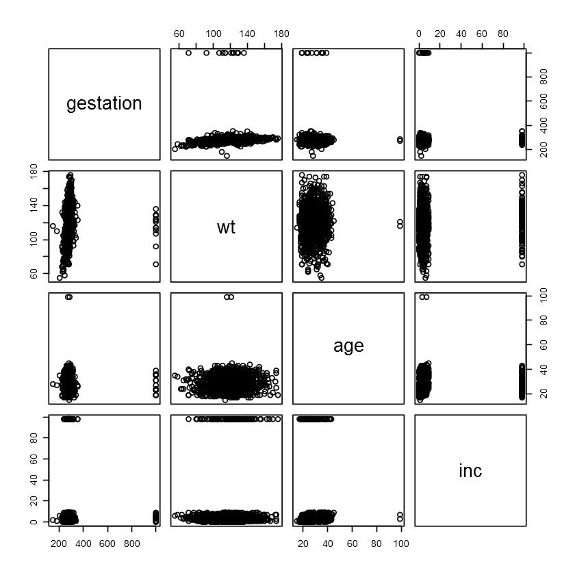

```r
# See if any relationships appear between the gestation time(gestation)
# birth weight(wt), mother's age(age) and family income(inc)

# Process the values used to refer to NAs (gestation=999, age=99, income=98)
attach(babies)
gestation[gestation==999] <- NA
age[age==99] <- NA
inc[inc==98] <- NA

# The result will be incorrect. We have changed the copies, not the original
# data frame.
pairs(babies[,c("gestation", "wt", "age", "inc")])
```

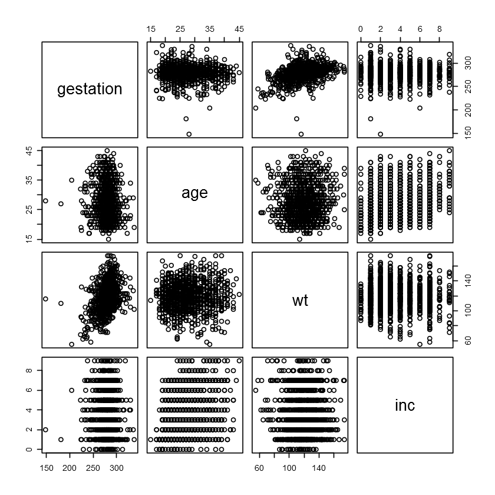

```r
# 'remove' the copies
rm(gestation);rm(age);rm(inc)
detach(babies); attach(babies)

# Guess what the values stored in the variable, 'not.these' would represent.
# '|' means 'OR', a logical operator
not.these = (gestation==999) | (age == 99) | (inc == 98)

# Make a new data frame. '!' is another logical operator, 'NOT'.
tmp <- babies[!not.these, c("gestation", "age", "wt", "inc")]

# Now you can see the scatterplots with gestation = 999, age = 99, inc = 98
# removed
pairs(tmp)
detach(babies)
```

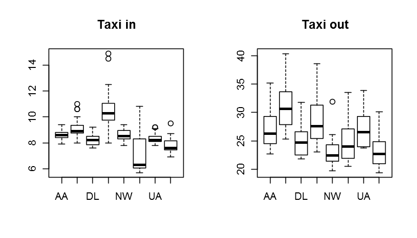

```r
par(mfrow=c(1,2))
options(repr.plot.height = 4)

# Access with logical vectors
attach(ewr)

# columns 3 through 10 are for the airlines

# This will plot the rows with the values of the variable "inorout" equal to "in"
# R will compare if a value of the variable "inorout" in every row is "in".
# If the result of the comparison is "TRUE", that row will be selected
# If the result of the comparison is "FALSE", that row will not be selected.
# Only the selected rows will be plotted
boxplot(ewr[inorout == "in", 3:10], main = "Taxi in")

# This will plot the rows with the values of the variable "inorout" equal to 'out'
boxplot(ewr[inorout == "out", 3:10], main = "Taxi out")
detach(ewr)
```

The argument to boxplot() is a data frame (=**boxplot**) and not a data vector (such as **boxplot$inorout**).

If the first argument to boxplot() is a list, then each component is plotted with separate boxplots. As a data frame is a list, this behavior makes using boxplot() much easier than typing in all the variable names. When a boxplot is called with a list, any names for the list are used to label the boxplot.

The subset() function An alternate to using using the [,] notation to extract values from a data frame is to use the subset() function:

**new.df=subset (old.df, subset=…, select=…)**

**subset=** -> use a logical condition to restrict the rows used

**select=** -> use a vector of the desired variable names or indices to restrict the columns

When we use subset (), the variable names are searched within the data frame. There is no need to attach the data frame or use with ().

The previous examples could have been completed as follows:

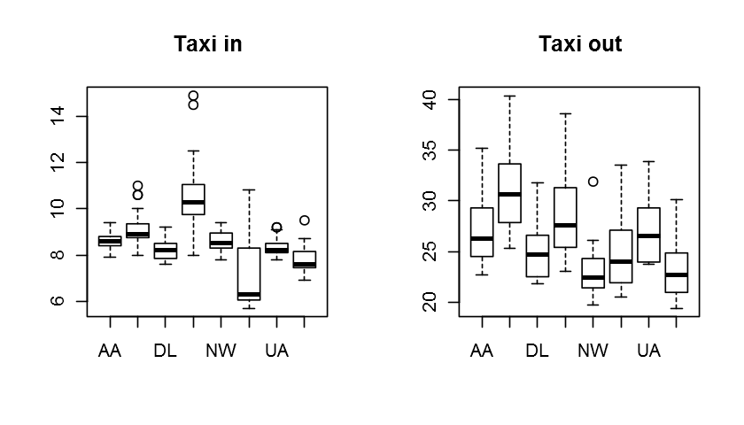

```r
par(mfrow=c(1,2))
options(repr.plot.height = 4)

# The argument 'subset=' uses a vector of logical values.
# inorout=="in" will return TRUE for the entries "in" and FALSE for "out"
ewr.in <- subset(ewr, subset=inorout=="in", select=3:10)
ewr.out <- subset(ewr, subset=inorout=="out", select=3:10)
boxplot(ewr.in, main="Taxi in")
boxplot(ewr.out, main="Taxi out")
```

```r
attach(mtcars)
sort(mpg)
```

1. 10.4

2. 10.4

3. 13.3

4. 14.3

5. 14.7

6. 15

7. 15.2

8. 15.2

9. 15.5

10. 15.8

11. 16.4

12. 17.3

13. 17.8

14. 18.1

15. 18.7

16. 19.2

17. 19.2

18. 19.7

19. 21

20. 21

21. 21.4

22. 21.4

23. 21.5

24. 22.8

25. 22.8

26. 24.4

27. 26

28. 27.3

29. 30.4

30. 30.4

31. 32.4

32. 33.9

```r
sort(mpg, decreasing=TRUE)
```

1. 33.9

2. 32.4

3. 30.4

4. 30.4

5. 27.3

6. 26

7. 24.4

8. 22.8

9. 22.8

10. 21.5

11. 21.4

12. 21.4

13. 21

14. 21

15. 19.7

16. 19.2

17. 19.2

18. 18.7

19. 18.1

20. 17.8

21. 17.3

22. 16.4

23. 15.8

24. 15.5

25. 15.2

26. 15.2

27. 15

28. 14.7

29. 14.3

30. 13.3

31. 10.4

32. 10.4

How can we sort a **data frame** by one of its **columns** and have the other columns reflect this new order?

-> *sort()* will not work.

-> *order()* is the one to use.

*order(x)* returns the indices of the sorted values of x, a data vector, so x[order(x)] will be x sorted from smallest to largest.

```r
x <- c(3, 2, 10, 4, 29)
# Indices are returned
order(x)

# ordered x; x[order(x)] = x[c(2,1,4,3,5)]
# Thus, it will return the second, the first, the fourth, the third,
# and the fifth value of x consequently.
x[order(x)]
```

1. 2

2. 1

3. 4

4. 3

5. 5

1. 2

2. 3

3. 4

4. 10

5. 29

```r
# sort mtcars by miles per gallon
# The blank behind ',' means 'select all columns'
mtcars[order(mpg),]
```

|  | mpg | cyl | disp | hp | drat | wt | qsec | vs | am | gear | carb |
| --- | --- | --- | --- | --- | --- | --- | --- | --- | --- | --- | --- |
| Cadillac Fleetwood | 10.4 | 8 | 472.0 | 205 | 2.93 | 5.250 | 17.98 | 0 | 0 | 3 | 4 |
| Lincoln Continental | 10.4 | 8 | 460.0 | 215 | 3.00 | 5.424 | 17.82 | 0 | 0 | 3 | 4 |
| Camaro Z28 | 13.3 | 8 | 350.0 | 245 | 3.73 | 3.840 | 15.41 | 0 | 0 | 3 | 4 |
| Duster 360 | 14.3 | 8 | 360.0 | 245 | 3.21 | 3.570 | 15.84 | 0 | 0 | 3 | 4 |
| Chrysler Imperial | 14.7 | 8 | 440.0 | 230 | 3.23 | 5.345 | 17.42 | 0 | 0 | 3 | 4 |
| Maserati Bora | 15.0 | 8 | 301.0 | 335 | 3.54 | 3.570 | 14.60 | 0 | 1 | 5 | 8 |
| Merc 450SLC | 15.2 | 8 | 275.8 | 180 | 3.07 | 3.780 | 18.00 | 0 | 0 | 3 | 3 |
| AMC Javelin | 15.2 | 8 | 304.0 | 150 | 3.15 | 3.435 | 17.30 | 0 | 0 | 3 | 2 |
| Dodge Challenger | 15.5 | 8 | 318.0 | 150 | 2.76 | 3.520 | 16.87 | 0 | 0 | 3 | 2 |
| Ford Pantera L | 15.8 | 8 | 351.0 | 264 | 4.22 | 3.170 | 14.50 | 0 | 1 | 5 | 4 |
| Merc 450SE | 16.4 | 8 | 275.8 | 180 | 3.07 | 4.070 | 17.40 | 0 | 0 | 3 | 3 |
| Merc 450SL | 17.3 | 8 | 275.8 | 180 | 3.07 | 3.730 | 17.60 | 0 | 0 | 3 | 3 |
| Merc 280C | 17.8 | 6 | 167.6 | 123 | 3.92 | 3.440 | 18.90 | 1 | 0 | 4 | 4 |
| Valiant | 18.1 | 6 | 225.0 | 105 | 2.76 | 3.460 | 20.22 | 1 | 0 | 3 | 1 |
| Hornet Sportabout | 18.7 | 8 | 360.0 | 175 | 3.15 | 3.440 | 17.02 | 0 | 0 | 3 | 2 |
| Merc 280 | 19.2 | 6 | 167.6 | 123 | 3.92 | 3.440 | 18.30 | 1 | 0 | 4 | 4 |
| Pontiac Firebird | 19.2 | 8 | 400.0 | 175 | 3.08 | 3.845 | 17.05 | 0 | 0 | 3 | 2 |
| Ferrari Dino | 19.7 | 6 | 145.0 | 175 | 3.62 | 2.770 | 15.50 | 0 | 1 | 5 | 6 |
| Mazda RX4 | 21.0 | 6 | 160.0 | 110 | 3.90 | 2.620 | 16.46 | 0 | 1 | 4 | 4 |
| Mazda RX4 Wag | 21.0 | 6 | 160.0 | 110 | 3.90 | 2.875 | 17.02 | 0 | 1 | 4 | 4 |
| Hornet 4 Drive | 21.4 | 6 | 258.0 | 110 | 3.08 | 3.215 | 19.44 | 1 | 0 | 3 | 1 |
| Volvo 142E | 21.4 | 4 | 121.0 | 109 | 4.11 | 2.780 | 18.60 | 1 | 1 | 4 | 2 |
| Toyota Corona | 21.5 | 4 | 120.1 | 97 | 3.70 | 2.465 | 20.01 | 1 | 0 | 3 | 1 |
| Datsun 710 | 22.8 | 4 | 108.0 | 93 | 3.85 | 2.320 | 18.61 | 1 | 1 | 4 | 1 |
| Merc 230 | 22.8 | 4 | 140.8 | 95 | 3.92 | 3.150 | 22.90 | 1 | 0 | 4 | 2 |
| Merc 240D | 24.4 | 4 | 146.7 | 62 | 3.69 | 3.190 | 20.00 | 1 | 0 | 4 | 2 |
| Porsche 914-2 | 26.0 | 4 | 120.3 | 91 | 4.43 | 2.140 | 16.70 | 0 | 1 | 5 | 2 |
| Fiat X1-9 | 27.3 | 4 | 79.0 | 66 | 4.08 | 1.935 | 18.90 | 1 | 1 | 4 | 1 |
| Honda Civic | 30.4 | 4 | 75.7 | 52 | 4.93 | 1.615 | 18.52 | 1 | 1 | 4 | 2 |
| Lotus Europa | 30.4 | 4 | 95.1 | 113 | 3.77 | 1.513 | 16.90 | 1 | 1 | 5 | 2 |
| Fiat 128 | 32.4 | 4 | 78.7 | 66 | 4.08 | 2.200 | 19.47 | 1 | 1 | 4 | 1 |
| Toyota Corolla | 33.9 | 4 | 71.1 | 65 | 4.22 | 1.835 | 19.90 | 1 | 1 | 4 | 1 |

```r
# best mpg first
mtcars[order(mpg, decreasing=TRUE),]
```

|  | mpg | cyl | disp | hp | drat | wt | qsec | vs | am | gear | carb |
| --- | --- | --- | --- | --- | --- | --- | --- | --- | --- | --- | --- |
| Toyota Corolla | 33.9 | 4 | 71.1 | 65 | 4.22 | 1.835 | 19.90 | 1 | 1 | 4 | 1 |
| Fiat 128 | 32.4 | 4 | 78.7 | 66 | 4.08 | 2.200 | 19.47 | 1 | 1 | 4 | 1 |
| Honda Civic | 30.4 | 4 | 75.7 | 52 | 4.93 | 1.615 | 18.52 | 1 | 1 | 4 | 2 |
| Lotus Europa | 30.4 | 4 | 95.1 | 113 | 3.77 | 1.513 | 16.90 | 1 | 1 | 5 | 2 |
| Fiat X1-9 | 27.3 | 4 | 79.0 | 66 | 4.08 | 1.935 | 18.90 | 1 | 1 | 4 | 1 |
| Porsche 914-2 | 26.0 | 4 | 120.3 | 91 | 4.43 | 2.140 | 16.70 | 0 | 1 | 5 | 2 |
| Merc 240D | 24.4 | 4 | 146.7 | 62 | 3.69 | 3.190 | 20.00 | 1 | 0 | 4 | 2 |
| Datsun 710 | 22.8 | 4 | 108.0 | 93 | 3.85 | 2.320 | 18.61 | 1 | 1 | 4 | 1 |
| Merc 230 | 22.8 | 4 | 140.8 | 95 | 3.92 | 3.150 | 22.90 | 1 | 0 | 4 | 2 |
| Toyota Corona | 21.5 | 4 | 120.1 | 97 | 3.70 | 2.465 | 20.01 | 1 | 0 | 3 | 1 |
| Hornet 4 Drive | 21.4 | 6 | 258.0 | 110 | 3.08 | 3.215 | 19.44 | 1 | 0 | 3 | 1 |
| Volvo 142E | 21.4 | 4 | 121.0 | 109 | 4.11 | 2.780 | 18.60 | 1 | 1 | 4 | 2 |
| Mazda RX4 | 21.0 | 6 | 160.0 | 110 | 3.90 | 2.620 | 16.46 | 0 | 1 | 4 | 4 |
| Mazda RX4 Wag | 21.0 | 6 | 160.0 | 110 | 3.90 | 2.875 | 17.02 | 0 | 1 | 4 | 4 |
| Ferrari Dino | 19.7 | 6 | 145.0 | 175 | 3.62 | 2.770 | 15.50 | 0 | 1 | 5 | 6 |
| Merc 280 | 19.2 | 6 | 167.6 | 123 | 3.92 | 3.440 | 18.30 | 1 | 0 | 4 | 4 |
| Pontiac Firebird | 19.2 | 8 | 400.0 | 175 | 3.08 | 3.845 | 17.05 | 0 | 0 | 3 | 2 |
| Hornet Sportabout | 18.7 | 8 | 360.0 | 175 | 3.15 | 3.440 | 17.02 | 0 | 0 | 3 | 2 |
| Valiant | 18.1 | 6 | 225.0 | 105 | 2.76 | 3.460 | 20.22 | 1 | 0 | 3 | 1 |
| Merc 280C | 17.8 | 6 | 167.6 | 123 | 3.92 | 3.440 | 18.90 | 1 | 0 | 4 | 4 |
| Merc 450SL | 17.3 | 8 | 275.8 | 180 | 3.07 | 3.730 | 17.60 | 0 | 0 | 3 | 3 |
| Merc 450SE | 16.4 | 8 | 275.8 | 180 | 3.07 | 4.070 | 17.40 | 0 | 0 | 3 | 3 |
| Ford Pantera L | 15.8 | 8 | 351.0 | 264 | 4.22 | 3.170 | 14.50 | 0 | 1 | 5 | 4 |
| Dodge Challenger | 15.5 | 8 | 318.0 | 150 | 2.76 | 3.520 | 16.87 | 0 | 0 | 3 | 2 |
| Merc 450SLC | 15.2 | 8 | 275.8 | 180 | 3.07 | 3.780 | 18.00 | 0 | 0 | 3 | 3 |
| AMC Javelin | 15.2 | 8 | 304.0 | 150 | 3.15 | 3.435 | 17.30 | 0 | 0 | 3 | 2 |
| Maserati Bora | 15.0 | 8 | 301.0 | 335 | 3.54 | 3.570 | 14.60 | 0 | 1 | 5 | 8 |
| Chrysler Imperial | 14.7 | 8 | 440.0 | 230 | 3.23 | 5.345 | 17.42 | 0 | 0 | 3 | 4 |
| Duster 360 | 14.3 | 8 | 360.0 | 245 | 3.21 | 3.570 | 15.84 | 0 | 0 | 3 | 4 |
| Camaro Z28 | 13.3 | 8 | 350.0 | 245 | 3.73 | 3.840 | 15.41 | 0 | 0 | 3 | 4 |
| Cadillac Fleetwood | 10.4 | 8 | 472.0 | 205 | 2.93 | 5.250 | 17.98 | 0 | 0 | 3 | 4 |
| Lincoln Continental | 10.4 | 8 | 460.0 | 215 | 3.00 | 5.424 | 17.82 | 0 | 0 | 3 | 4 |